# Homework #1

### Tasks

```matlab
data = readtable("cleveland_data_revised.xlsx");

% below code works for original data set
%[num, txt] = xlsread("clevelanddata_dec2019.xlsx");
```

```matlab
size(data)   %total rows and columns
```

ans = 1×2

303 14

```matlab
sum(ismissing(data),"all")   %find total # of missing values
```

ans = 6

Find individuals with max HR and cholest

```matlab
[M,I] = max(data.maxHR)
```

M = 202

I = 133

```matlab
[M1,I1] = max(data.cholest)
```

M1 = 564

I1 = 153

Find avg BP and HR for individuals with and withouot heart disease

```matlab
 BP1 = mean(data.restingBP(data.diseaseSeverity>0))
```

BP1 = 134.5683

```matlab
HR1 = mean(data.maxHR(data.diseaseSeverity>0))
```

HR1 = 139.2590

```matlab
BP2 = mean(data.restingBP(data.diseaseSeverity==0))
```

BP2 = 129.2500

```matlab
HR2 = mean(data.maxHR(data.diseaseSeverity==0))
```

HR2 = 158.3780

Diagnosis of heart disease: BP = 134.6, HR = 139.26.

No heart disease: BP = 129.3, HR = 158.38.

Heart disease involves narrowed or blocked blood vessels, which restricts blood flow and thereby increase blood pressure. Our data set confirms this trend. However, the patients in the data set without heart disease have a higher heart rate on average compared to those with heart disease. This is surprising because heart disease is typically associated with an increased heart rate.

# 25 min

### Do the following:

Plot BP vs Cholesterol and differentiate normal vs disease

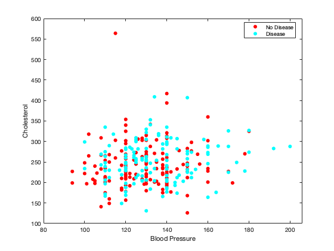

```matlab
disease = data.diseaseSeverity > 0;   % Create new var for diseased (1 = diseased)

gscatter(data.restingBP, data.cholest,disease)
legend('No Disease','Disease')
xlabel('Blood Pressure')
ylabel('Cholesterol')
```

Distribution of HR and ECG ST depression

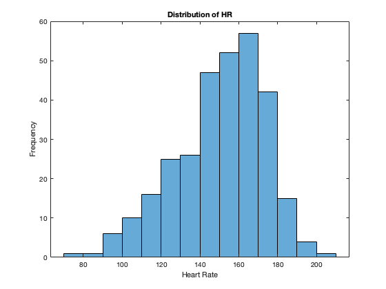

```matlab
histogram(data.maxHR)
xlabel('Heart Rate')
ylabel('Frequency')
title('Distribution of HR')
```

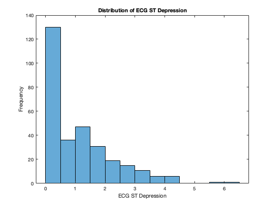

```matlab
histogram(data.ECGDepression)
xlabel('ECG ST Depression')
ylabel('Frequency')
title('Distribution of ECG ST Depression')
```

Plot first 10 variables using gplotmatrix

```matlab
% Need below lines for original dataset
%data.thaliumTest = cell2mat(data.thaliumTest);
%data.fluoroscopy = cell2mat(data.flourosopy);
data_10 = table2array(data(:,1:10));
vars_10 = data.Properties.VariableNames(1:10)
```

vars_10 = 1×10 cell array

{'Age'} {'SEX'} {'chestPain'} {'restingBP'} {'cholest'} {'highBloodSugar'} {'ECG'} {'maxHR'} {'angina'} {'ECGDepression'}

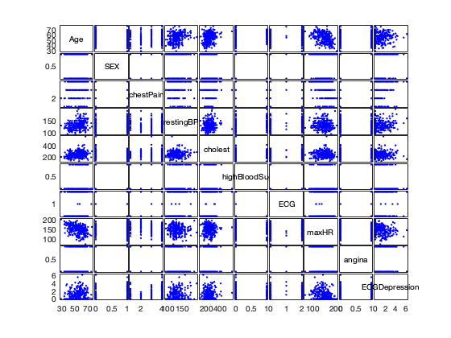

Warning: Error updating Text.  
String scalar or character vector must have valid interpreter syntax:  
angina_

```matlab
gplotmatrix(data_10,[],[],[],[],[],[],'variable',vars_10);
```

# 25 min (including ~10 min for fixing issue with two cell columns)

### Correlation

Find properties that are most and least strongly correlated with degree of heart disease

```matlab
%remove missing data for corr function
r = splitvars(table(corr(data_rm.Variables,data_rm.diseaseSeverity,"rows","complete")));
r.Properties.RowNames = data.Properties.VariableNames
```

r = 14×1 table

|  | Var1 |
| --- | --- |
| 1 Age | 0.2222 |
| 2 SEX | 0.2268 |
| 3 chestPain | 0.4042 |
| 4 restingBP | 0.1596 |
| 5 cholest | 0.0664 |
| 6 highBloodSugar | 0.0490 |
| 7 ECG | 0.1841 |
| 8 maxHR | -0.4206 |
| 9 angina | 0.3916 |
| 10 ECGDepression | 0.5015 |
| ⋮ |  |

The highest correlated features are from columns 10 (depression) and 13 (thal).

The least correlated features are from columns 5 (cholesterol) and columns 6 (high blood sugar).

Repeat analysis for males and females, separately.

```matlab
% extract data by sex
male = data(data.SEX==0,:);
female = data(data.SEX==1,:);

% created sorted correlation tables
r_male = splitvars(table(corr(male.Variables,male.diseaseSeverity,"rows","complete")));
r_male.Properties.RowNames = data.Properties.VariableNames;
sortrows(r_male)
```

ans = 14×1 table

|  | Var1 |
| --- | --- |
| 1 maxHR | -0.2667 |
| 2 cholest | 0.1219 |
| 3 Age | 0.2000 |
| 4 ECG | 0.2212 |
| 5 highBloodSugar | 0.2574 |
| 6 angina | 0.3118 |
| 7 chestPain | 0.3982 |
| 8 restingBP | 0.4274 |
| 9 slopeST | 0.4444 |
| 10 ECGDepression | 0.6100 |
| ⋮ |  |

Highest correlated features for males are thaliumTest and fluoroscopy.

Lowest correlated features for males are age and cholesterol.

```matlab
r_female = splitvars(table(corr(female.Variables,female.diseaseSeverity,"rows","complete")));
r_female.Properties.RowNames = data.Properties.VariableNames;
sortrows(r_female)
```

ans = 14×1 table

|  | Var1 |
| --- | --- |
| 1 maxHR | -0.4666 |
| 2 highBloodSugar | -0.0360 |
| 3 restingBP | 0.0715 |
| 4 cholest | 0.1218 |
| 5 ECG | 0.1667 |
| 6 Age | 0.2743 |
| 7 slopeST | 0.3534 |
| 8 angina | 0.3933 |
| 9 thalliumTest | 0.4044 |
| 10 chestPain | 0.4181 |
| ⋮ |  |

Highest correlated features for females are max HR and fluoroscopy.

Lowest correlated features for females are resting BP and high blood sugar.

Find pairwaise rank correlations between all 14 variables and visualize with heatmap

```matlab
data_rm = rmmissing(data);
rank = corr(data_rm.Variables,"type","Spearman")
```

rank = 14×14

1.0000 -0.0954 0.1327 0.2996 0.1834 0.1246 0.1482 -0.3926 0.0887 0.2519 0.1735 0.3818 0.1268 0.2424 -0.0954 1.0000 0.0412 -0.0636 -0.1534 0.0389 0.0339 -0.0563 0.1436 0.1123 0.0271 0.1031 0.3753 0.2598 0.1327 0.0412 1.0000 0.0005 0.0732 -0.0654 0.0921 -0.3807 0.4242 0.2449 0.2042 0.2636 0.3103 0.4812 0.2996 -0.0636 0.0005 1.0000 0.1392 0.1555 0.1458 -0.0468 0.0524 0.1558 0.0890 0.0783 0.1114 0.1411 0.1834 -0.1534 0.0732 0.1392 1.0000 0.0170 0.1625 -0.0348 0.0832 0.0241 -0.0034 0.1348 0.0038 0.1044 0.1246 0.0389 -0.0654 0.1555 0.0170 1.0000 0.0688 -0.0102 -0.0009 0.0262 0.0313 0.1436 0.0546 0.0354 0.1482 0.0339 0.0921 0.1458 0.1625 0.0688 1.0000 -0.1052 0.0819 0.1044 0.1396 0.1277 0.0153 0.1806 -0.3926 -0.0563 -0.3807 -0.0468 -0.0348 -0.0102 -0.1052 1.0000 -0.4047 -0.4367 -0.4380 -0.2899 -0.2920 -0.4493 0.0887 0.1436 0.4242 0.0524 0.0832 -0.0009 0.0819 -0.4047 1.0000 0.2959 0.2666 0.1820 0.3249 0.4270 0.2519 0.1123 0.2449 0.1558 0.0241 0.0262 0.1044 -0.4367 0.2959 1.0000 0.5936 0.2654 0.3568 0.4604

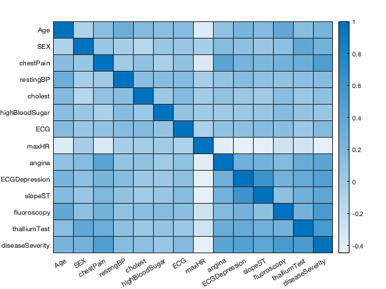

```matlab
heatmap(rank,"XDisplayLabels",data_rm.Properties.VariableNames,"YDisplayLabels",...
    data_rm.Properties.VariableNames);
```

It appears that several features are negatively correlated with Feature 8 (max heart rate). This suggests that the higher a patient's heart rate, the lower their chances of cardiovascular complications. There are several features with strong positive correlations with heart disease diagnosis. For example, heart rate diagnosis seems to increase with thaliumTest and number of major vessels colored by fluoroscopy.

# 25 min

### Box plots

Compare max HR, ECG ST depression, resting BP vs 4 levels of heart disease

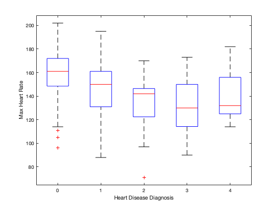

```matlab
boxplot(data.maxHR, data.diseaseSeverity)
xlabel('Heart Disease Diagnosis')
ylabel('Max Heart Rate')
```

It appears that heart rate actually decreases with the severity of the patient's heart disease diagnosis, until the diagnosis reaches level 4, where the average HR increases again.

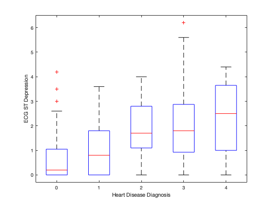

```matlab
boxplot(data.ECGDepression, data.diseaseSeverity)
xlabel('Heart Disease Diagnosis')
ylabel('ECG ST Depression')
```

ECG ST depression clearly increases with heart disease diagnosis.

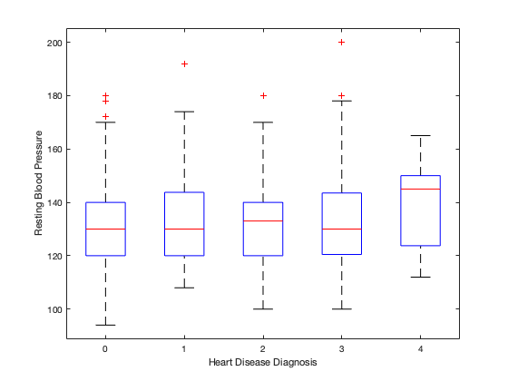

```matlab
boxplot(data.restingBP, data.diseaseSeverity)
xlabel('Heart Disease Diagnosis')
ylabel('Resting Blood Pressure')
```

It appears that resting blood pressure is not strongly related to heart disease diagnosis. Although, patients with a level 4 diagnosis do have a higher mean BP.

Use subplot to make 10 boxplots in a 4x3 grid. Compare first 10 variables vs 2 levels of heart disease (absent, present).

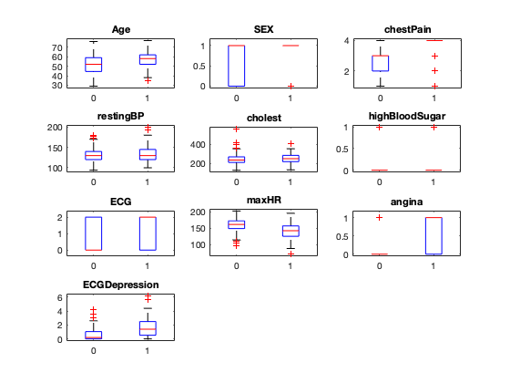

```matlab
for i = 1:10
    subplot(4,3,i)
    boxplot(data.(i),disease)
    title(data.Properties.VariableNames(i))
end
```

- those with heart disease (HD) tend to be older
- median resting blood pressure is not different, but those with HD do have a larger range of BP values
- median heart rate is lower for patients with HD
- ECG ST depression is significantly higher for patients with HD

# 30 min